# Práctica 9. Reconstrucción filogenética

Autor/a

Laura Monleón Vicente

Fecha de publicación

9 de mayo de 2026

# Introducción

Aunque existen muy buenos programas para inferir filogenias fuera del entorno de R, como RAxML o IQ-TREE, trabajar dentro de R tiene una ventaja importante: los árboles se pueden representar, manipular, comparar, enraizar, exportar y analizar como objetos propios del lenguaje. En esta práctica se trabaja principalmente con los paquetes `phangorn` y `ape`. El paquete `phangorn` permite inferir árboles filogenéticos mediante métodos basados en distancias y máxima verosimilitud, mientras que `ape` proporciona funciones muy útiles para manipular árboles de clase `phylo`, calcular distancias, representar filogenias y estimar fechas mediante métodos simples.

El objetivo general de esta práctica es obtener una filogenia de homininos y algunos primates a partir de un alineamiento de genomas mitocondriales completos. Las secuencias mitocondriales son especialmente útiles para este tipo de análisis porque son relativamente cortas, se alinean con facilidad y acumulan sustituciones a lo largo del tiempo. Sin embargo, también tienen limitaciones: representan únicamente la historia materna, pueden presentar tasas evolutivas diferentes entre linajes y no reflejan necesariamente la historia completa del genoma nuclear.

# Objetivos

El objetivo principal es reconstruir y analizar una filogenia calibrada de homininos y otros primates a partir de secuencias mitocondriales.

De forma más concreta, se pretende:

1. Cargar un alineamiento de genomas mitocondriales en formato FASTA.
2. Confirmar el número de secuencias, la longitud del alineamiento y los nombres de las muestras.
3. Inferir árboles rápidos basados en distancias mediante NJ y UPGMA.
4. Enraizar árboles mediante distintos criterios: nodo interno, outgroup, punto medio y regresión raíz-punta.
5. Comparar distancias evolutivas entre grupos.
6. Filtrar secuencias idénticas o redundantes.
7. Seleccionar modelos de evolución molecular.
8. Ajustar un árbol de máxima verosimilitud.
9. Explorar la datación de árboles usando edades de las puntas y calibración interna.

# Preparación

```r
# Cargamos los paquetes necesarios para la práctica.
# phangorn carga automáticamente ape, pero lo cargamos también explícitamente
# para dejar claro qué funciones proceden de cada paquete.

library(phangorn)
library(ape)
```

# Datos

El archivo de entrada debe llamarse `mtDNA.fasta` y debe estar guardado en la carpeta `../../data/`, es decir, en la carpeta `data` del repositorio. Contiene un alineamiento en formato FASTA de 42 cromosomas mitocondriales completos de primates y homininos: gorila, chimpancés, bonobos, un individuo de *Homo heidelbergensis*, humanos denisovanos, humanos neandertales y humanos anatómicamente modernos.

```r
# Comprobamos que el archivo existe antes de intentar cargarlo.
archivo_mtdna <- "../../data/mtDNA.fasta"

if (!file.exists(archivo_mtdna)) {
  stop("No se encuentra ../../data/mtDNA.fasta. Debes guardar el alineamiento en la carpeta data del repositorio.")
}

mtdna <- read.phyDat(archivo_mtdna, format = "fasta")
mtdna
```

```
42 sequences with 16603 character and 974 different site patterns.
The states are a c g t
```

Después de ejecutar el bloque anterior, los datos quedan almacenados en el objeto `mtdna`, que pertenece a la clase `phyDat`. Esta clase es la que utiliza `phangorn` para trabajar con alineamientos en análisis filogenéticos.

## Ejercicio: comprobación inicial del alineamiento

> ¿Puedes confirmar el número de secuencias? ¿Qué longitud tiene el alineamiento? ¿Qué función usarías para extraer los nombres de las secuencias?

```r
# Número de secuencias:
n_secuencias <- length(mtdna)

# Longitud del alineamiento:
longitud_alineamiento <- attr(mtdna, "nr")

# Nombres de las secuencias:
nombres_secuencias <- names(mtdna)

n_secuencias
```

```
[1] 42
```

```r
longitud_alineamiento
```

```
[1] 974
```

```r
head(nombres_secuencias)
```

```
[1] "G.gorilla_D38114"       "P.troglodytes_JF727212" "P.troglodytes_JN191207"
[4] "P.troglodytes_JF727168" "P.troglodytes_HM068590" "P.paniscus_KX211934"
```

También podemos visualizar información básica del objeto con `glance()`:

```r
glance(mtdna)
```

```
  nseq nchar unique_site_pattern parsimony_informative_sites const_sites
1   42 16603                 974                        2047       13482
```

El número de secuencias aparece indicado como nseq y es igual a 42. La longitud del alineamiento la vemos comp nchar= 16603. También podemos verlo de forma aproximada representando en forma de imagen el alineamiento con la función image(mtdna). Para saber los nombres que conforman el alineamiento utilizamos la función “names(mtdna)”.

# Árboles basados en distancias

Los métodos basados en distancias, como NJ (*neighbor joining*) y UPGMA, permiten obtener una primera aproximación rápida a la relación filogenética entre las secuencias. Estos métodos no modelizan el proceso evolutivo con la misma precisión que la máxima verosimilitud, pero son útiles para explorar los datos, detectar grupos principales y comprobar si existen secuencias problemáticas.

Primero calculamos una matriz de distancias usando el modelo F81 y después construimos los árboles NJ y UPGMA.

```r
distancias <- dist.ml(mtdna, model = "F81")

mt_nj <- NJ(distancias)

mt_upgma <- upgma(distancias)

class(mt_nj)
```

```
[1] "phylo"
```

```r
class(mt_upgma)
```

```
[1] "phylo"
```

Los objetos `mt_nj` y `mt_upgma` pertenecen a la clase `phylo`, que es la clase estándar usada por `ape` para representar árboles filogenéticos.

## Ejercicio: estructura y representación de los árboles

> ¿De qué clase son los objetos `mt_nj` y `mt_upgma`? Consulta la estructura de estos objetos (`str(mt_nj)`). Represéntalos gráficamente (`plot(mt_nj)`) y consulta la ayuda de la función `plot.phylo()` para saber qué opciones de representación gráfica tienes. ¿Para qué sirven las funciones `add.scale.bar()` y `axisPhylo()`?

```r
str(mt_nj)
```

```
List of 4
 $ edge       : int [1:81, 1:2] 47 47 54 54 53 53 52 52 51 51 ...
 $ edge.length: num [1:81] 6.03e-05 5.20e-08 -4.37e-08 4.37e-08 8.51e-08 ...
 $ tip.label  : chr [1:42] "G.gorilla_D38114" "P.troglodytes_JF727212" "P.troglodytes_JN191207" "P.troglodytes_JF727168" ...
 $ Nnode      : int 40
 - attr(*, "class")= chr "phylo"
 - attr(*, "order")= chr "postorder"
```

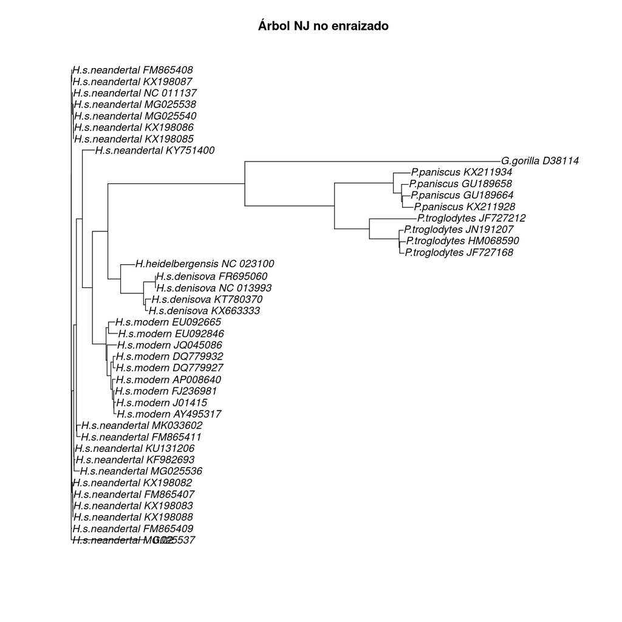

```r
plot(mt_nj, main = "Árbol NJ no enraizado")
add.scale.bar()
```

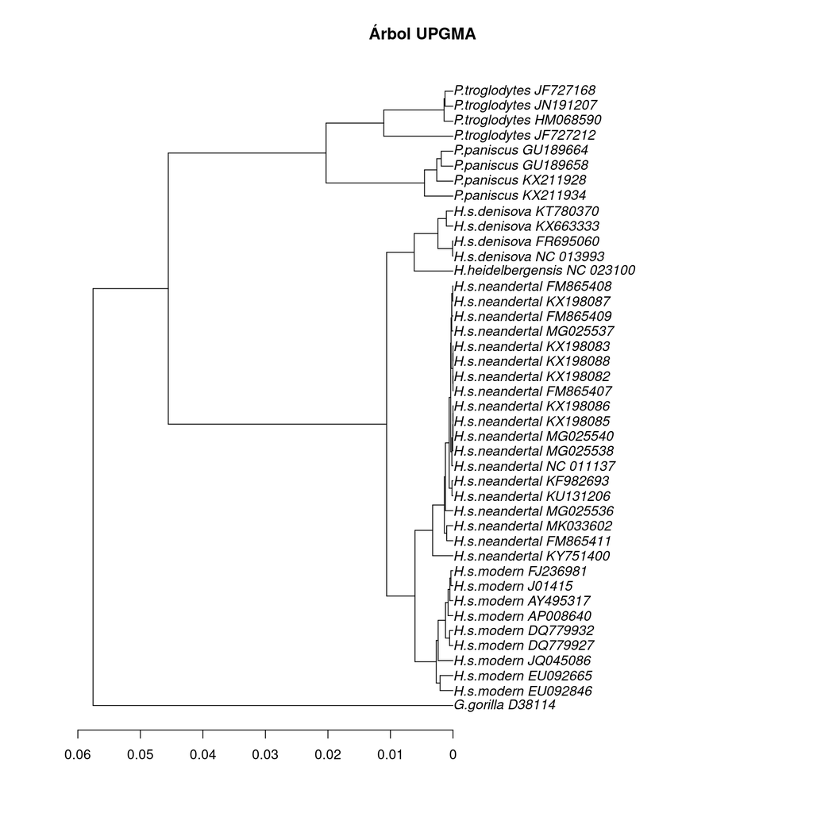

```r
plot(mt_upgma, main = "Árbol UPGMA")
axisPhylo()
```

Los objetos `mt_nj` y `mt_upgma` son árboles de clase `phylo`. Internamente contienen, entre otros elementos, una matriz `edge` que define la conectividad entre nodos, un vector `tip.label` con los nombres de las hojas y un vector `edge.length` con las longitudes de rama.

La función `add.scale.bar()` añade una barra de escala al árbol, útil para interpretar las longitudes de ramas como cantidad de cambio evolutivo. La función `axisPhylo()` añade un eje filogenético, especialmente útil en árboles ultramétricos o datados, donde las distancias pueden interpretarse como tiempo o como distancia evolutiva acumulada desde la raíz.

# Enraizar

El árbol NJ inicial no está enraizado. En un árbol no enraizado se representan relaciones de proximidad, pero no se especifica una dirección temporal ni un ancestro común situado en una raíz concreta.

```r
is.rooted(mt_nj)
```

```
[1] FALSE
```

## Escogiendo el nodo

Una forma de enraizar el árbol es elegir un nodo interno. Para identificar nodos internos podemos representar el árbol y añadir etiquetas a los nodos.

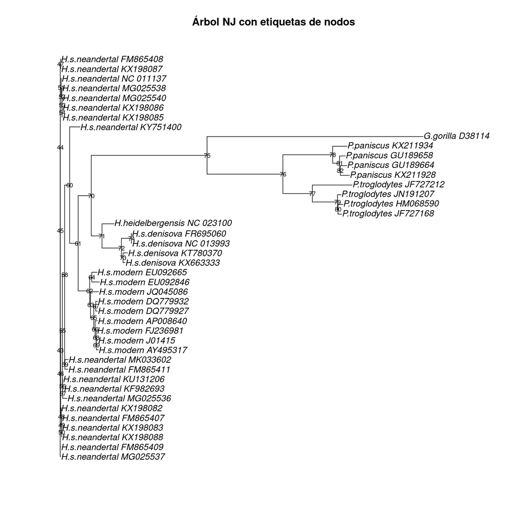

```r
plot(mt_nj, main = "Árbol NJ con etiquetas de nodos")
nodelabels(frame = "none", cex = 0.7)
```

El nodo 75 se puede usar como ejemplo de nodo de enraizado, como indicaba el guion original. Sin embargo, la numeración de nodos puede ser frágil y cambiar si cambia el árbol o el orden de las secuencias. Por eso, aunque lo probamos, después usaremos un outgroup.

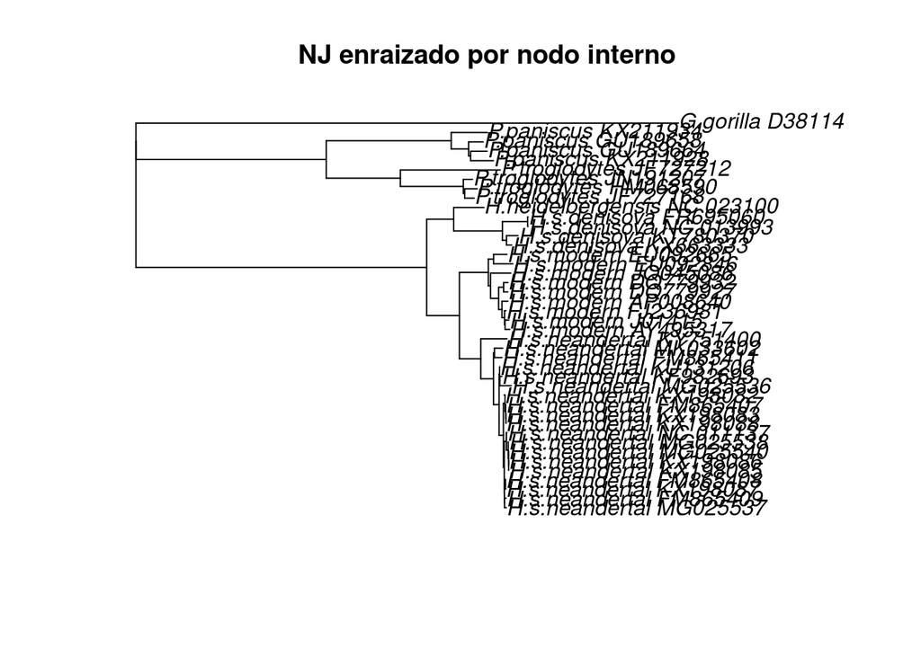

```r
mt_nj_rooted_node <- tryCatch(
  root(mt_nj, node = 75, resolve.root = TRUE),
  error = function(e) {
    message("No se pudo enraizar por el nodo 75. Se conserva el árbol original.")
    mt_nj
  }
)

plot(mt_nj_rooted_node, main = "NJ enraizado por nodo interno")
```

## Con un outgroup

Es más robusto enraizar usando un outgroup. En este caso, el gorila es una buena referencia externa respecto al conjunto formado por chimpancés, bonobos y humanos.

```r
if ("G.gorilla_D38114" %in% mt_nj$tip.label) {
  mt_nj_rooted <- root(mt_nj, outgroup = "G.gorilla_D38114", resolve.root = TRUE)
} else {
  mt_nj_rooted <- mt_nj
}

is.rooted(mt_nj_rooted)
```

```
[1] TRUE
```

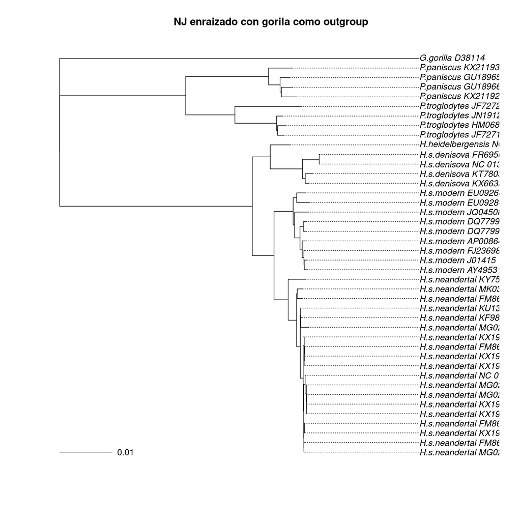

```r
plot(mt_nj_rooted, align.tip.label = TRUE, main = "NJ enraizado con gorila como outgroup")
add.scale.bar()
```

El gorila puede utilizarse como grupo externo para orientar el árbol porque está fuera del grupo principal de homínidos comparado. Si la secuencia no estuviera disponible, el enraizamiento por punto medio sería una alternativa razonable.

Los denisovanos tenían un linaje mitocondrial muy divergente pero estos compartían ancestros más cercanos con los Neandertales que con los Heidelbergensis por lo tanto esto no es representativo. Podemos utilizar un par de funciones interesantes siendo: estimate.mu() así consulto la ayuda, me hace una función que me data las puntas y los nodos. Me permite estudiar el reloj molecular. Todo esto lo aplica internamente: estimate.dates() Lo que estamos haciendo cuando le damos las edades de los nodos, cuando le añado el vector node.dates, le puedo dar las unidades en millones de años o en años, asegurandome que todas las fechas están en negativo y en las mismas unidades. (ejemplo: -6,5, -6,4, -0,4).

## En el punto medio

Otra opción es enraizar en el punto medio con `midpoint()`. Este método coloca la raíz en el punto que equilibra las distancias entre hojas, pero asume implícitamente que las tasas evolutivas son suficientemente homogéneas.

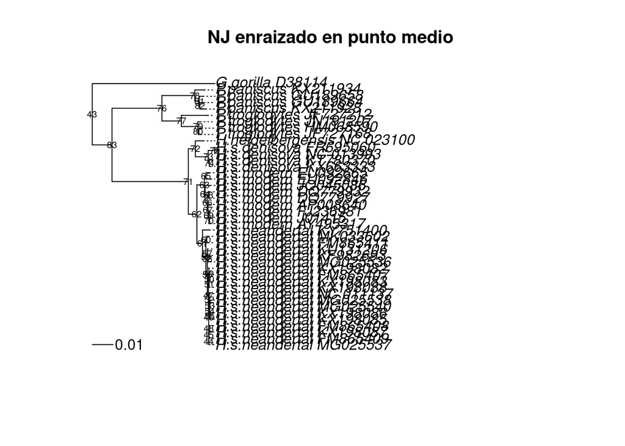

```r
mt_nj_midpoint <- midpoint(mt_nj)

plot(mt_nj_midpoint, align.tip.label = TRUE, main = "NJ enraizado en punto medio")
nodelabels(frame = "none", cex = 0.6)
add.scale.bar()
```

# Con datación de hojas

En este conjunto de datos no todas las secuencias son contemporáneas. Hay secuencias actuales y secuencias arcaicas. Por tanto, podemos usar la edad estimada de las puntas para situar la raíz mediante una regresión raíz-punta con `rtt()`.

```r
fechas <- c(0, 0, 0, 0, 0, 0, 0, 0, 0,
            -400000,
            -39000, -50000, -110000, -110000,
            -39820, -40096, -38515, -38310, -39000, -40000, -41210,
            -42430, -42540, -43230, -43780, -44290, -44770, -49000,
            -50000, -82752, -65000, -122287, -110450,
            0, 0, 0, 0, 0, 0, 0, 0, 0)

# Ajustamos el vector de fechas a los nombres reales de las secuencias.
if (length(fechas) != length(mt_nj$tip.label)) {
  stop("El vector de fechas no tiene la misma longitud que el número de puntas del árbol.")
}

fechas <- setNames(fechas, mt_nj$tip.label)

head(fechas)
```

```
      G.gorilla_D38114 P.troglodytes_JF727212 P.troglodytes_JN191207
                     0                      0                      0
P.troglodytes_JF727168 P.troglodytes_HM068590    P.paniscus_KX211934
                     0                      0                      0
```

```r
tail(fechas)
```

```
H.s.modern_DQ779927 H.s.modern_DQ779932 H.s.modern_AP008640 H.s.modern_AY495317
                  0                   0                   0                   0
  H.s.modern_J01415 H.s.modern_FJ236981
                  0                   0
```

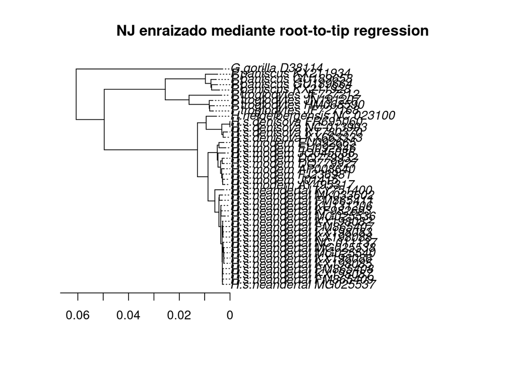

```r
mt_nj_rtt <- rtt(mt_nj, tip.dates = fechas, objective = "rms")

plot(mt_nj_rtt, align.tip.label = TRUE, main = "NJ enraizado mediante root-to-tip regression")
axisPhylo()
```

## Ejercicio: interpretación de la datación de puntas

> ¿Se corresponden bien las distancias evolutivas estimadas con las dataciones? ¿Qué secuencias crees que se ajustan menos a su supuesta edad? ¿Qué razones puede haber para que la edad de una secuencia no se corresponda con la cantidad de cambios que ha acumulado?

La correspondencia entre distancias evolutivas y dataciones no es perfecta. En teoría, si el reloj molecular fuese estricto, las secuencias más antiguas deberían mostrar una distancia raíz-punta menor que las secuencias actuales, porque dejaron de acumular mutaciones antes. Sin embargo, las diferencias temporales entre muchas secuencias arcaicas son pequeñas en comparación con la profundidad total del árbol, especialmente frente a la divergencia entre humanos y chimpancés.

Las secuencias que menos se ajustan a su supuesta edad serían aquellas que quedan situadas a distancias raíz-punta inesperadamente largas o cortas respecto a su datación. Esto puede deberse a errores de datación, degradación o daño molecular en ADN antiguo, posiciones ambiguas, errores de secuenciación, diferencias reales en tasa evolutiva entre linajes o limitaciones del modelo usado para estimar distancias.

Llama la atención quelos denisovanos son los que menos se corresponden con su edad real. Puede ser por datación de fósiles muy imprecisa, si utilizo la media del margen de edad de los fósiles puedo equivocarme muhco. Puedo contener cambios que sean producto de la degradación de DNA desde que se encontró el fósil o se creo hasta que ha sido secuenciado. Por ejemplo, puede haber sucedido degradación de timinas, algunas de estas mutaciones pueden ser por lo tanto, errores de secuenciación o producto de degradación del DNA tal y como hemos mencionado. Lo único de lo que estamos seguros es de que aquí se han producido más cambios.

# Distancias

La matriz de distancias permite comparar cuantitativamente grupos de secuencias.

```r
distMat <- as.matrix(distancias)

modernos     <- startsWith(colnames(distMat), "H.s.modern")
neandertales <- startsWith(colnames(distMat), "H.s.neandertal")
denisovanos  <- startsWith(colnames(distMat), "H.s.denisova")
chimpances   <- startsWith(colnames(distMat), "P.troglodytes")
bonobos      <- startsWith(colnames(distMat), "P.paniscus")
gorila       <- startsWith(colnames(distMat), "G.gorilla")
heidelberg   <- startsWith(colnames(distMat), "H.heidelbergensis")

mean_hum_neand <- mean(distMat[modernos, neandertales])
mean_hum_neand
```

```
[1] 0.01214282
```

## Ejercicio: distancias medias entre grupos

> Calcula las distancias medias entre todos los grupos. ¿Cuántas veces mayor es la distancia entre humanos y chimpancés que entre humanos y neandertales? ¿Cómo calcularías la distancia media entre dos secuencias de humanos modernos?

```r
grupos <- list(
  Modernos = modernos,
  Neandertales = neandertales,
  Denisovanos = denisovanos,
  Chimpances = chimpances,
  Bonobos = bonobos,
  Gorila = gorila,
  Heidelbergensis = heidelberg
)

dist_media_grupos <- matrix(NA_real_,
                            nrow = length(grupos),
                            ncol = length(grupos),
                            dimnames = list(names(grupos), names(grupos)))

for (i in names(grupos)) {
  for (j in names(grupos)) {
    dist_media_grupos[i, j] <- mean(distMat[grupos[[i]], grupos[[j]]], na.rm = TRUE)
  }
}

round(dist_media_grupos, 5)
```

```
                Modernos Neandertales Denisovanos Chimpances Bonobos  Gorila
Modernos         0.00333      0.01214     0.02251    0.09104 0.09239 0.11565
Neandertales     0.01214      0.00176     0.02201    0.09041 0.09089 0.11546
Denisovanos      0.02251      0.02201     0.00269    0.09130 0.09298 0.11706
Chimpances       0.09104      0.09041     0.09130    0.00933 0.04059 0.11255
Bonobos          0.09239      0.09089     0.09298    0.04059 0.00518 0.11374
Gorila           0.11565      0.11546     0.11706    0.11255 0.11374 0.00000
Heidelbergensis  0.01709      0.01755     0.01241    0.08842 0.08908 0.11275
                Heidelbergensis
Modernos                0.01709
Neandertales            0.01755
Denisovanos             0.01241
Chimpances              0.08842
Bonobos                 0.08908
Gorila                  0.11275
Heidelbergensis         0.00000
```

```r
dist_hum_chimp <- mean(distMat[modernos, chimpances], na.rm = TRUE)
dist_hum_neand <- mean(distMat[modernos, neandertales], na.rm = TRUE)

ratio_hum_chimp_vs_neand <- dist_hum_chimp / dist_hum_neand

dist_hum_chimp
```

```
[1] 0.09104153
```

```r
dist_hum_neand
```

```
[1] 0.01214282
```

```r
ratio_hum_chimp_vs_neand
```

```
[1] 7.497561
```

La distancia media entre humanos modernos y chimpancés es aproximadamente 7.5 veces mayor que la distancia media entre humanos modernos y neandertales. Esto es coherente con la historia evolutiva esperada: la separación entre humanos y chimpancés es mucho más antigua que la separación entre humanos modernos y neandertales.

Para calcular la distancia media entre dos secuencias de humanos modernos evitando comparar cada secuencia consigo misma, podemos usar la semimatriz inferior:

```r
dist_modernos <- distMat[modernos, modernos]
mean_modernos <- mean(dist_modernos[lower.tri(dist_modernos)], na.rm = TRUE)
mean_modernos
```

```
[1] 0.003747961
```

# Distancias cofenéticas

En los árboles, las distancias entre hojas se representan mediante la suma de las longitudes de las ramas que las conectan. Estas distancias se pueden obtener con `cophenetic()`.

```r
distCofen <- cophenetic(mt_nj_rooted)

# Comparamos las distancias estimadas directamente con las distancias cofenéticas
# del árbol NJ enraizado.
comparacion_distancias <- data.frame(
  estimadas = as.vector(distMat),
  cofeneticas = as.vector(as.matrix(distCofen))
)

head(comparacion_distancias)
```

```
  estimadas cofeneticas
1 0.0000000   0.0000000
2 0.1132354   0.1146673
3 0.1122704   0.1111627
4 0.1122038   0.1113715
5 0.1124787   0.1117631
6 0.1125732   0.1130582
```

```r
cor(comparacion_distancias$estimadas, comparacion_distancias$cofeneticas,
    use = "complete.obs")
```

```
[1] 0.999936
```

## Ejercicio: comparación entre distancias estimadas y cofenéticas

Las distancias cofenéticas del árbol NJ se parecen mucho a las distancias originales, porque el árbol NJ se construyó precisamente a partir de esa matriz. Aun así, no son idénticas, ya que un árbol es una representación simplificada de una matriz completa de distancias. La correlación entre ambas medidas permite evaluar hasta qué punto el árbol conserva la información de distancia contenida en la matriz original.

# Limpieza o filtrado del alineamiento

Las distancias crudas permiten detectar secuencias idénticas. Esto es importante porque algunas funciones pueden generar problemas si dos secuencias idénticas tienen edades diferentes.

```r
crudas <- dist.dna(as.DNAbin(mtdna), model = "raw")
crudas <- as.matrix(crudas)

identicas <- which(crudas == 0 & lower.tri(crudas), arr.ind = TRUE)

identicas
```

```
                        row col
H.s.neandertal_KX198086  16  15
H.s.neandertal_MG025540  23  15
H.s.neandertal_MG025540  23  16
H.s.neandertal_KX198088  21  20
H.s.neandertal_KX198083  22  20
H.s.neandertal_KX198082  27  20
H.s.neandertal_KX198083  22  21
H.s.neandertal_KX198082  27  21
H.s.neandertal_KX198082  27  22
```

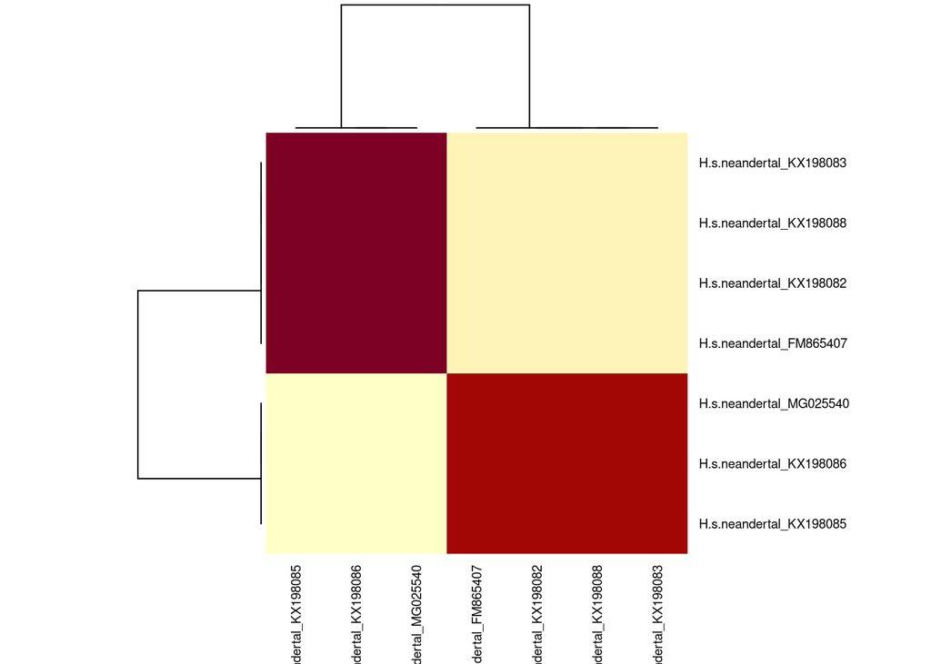

```r
if (nrow(identicas) > 0) {
  repetidas <- unique(c(identicas[, "row"], identicas[, "col"]))
  heatmap(crudas[repetidas, repetidas], cexRow = 0.7, cexCol = 0.7)
} else {
  message("No se han detectado secuencias idénticas.")
}
```

Según el guion, se conservan las secuencias `MG025540` y `FM865407` como representantes de dos grupos de secuencias neandertales idénticas o casi redundantes. Eliminamos las otras copias para evitar problemas posteriores.

```r
mtdna37 <- mtdna[!grepl("(KX198085|KX198086|KX198082|KX198088|KX198083)",
                        names(mtdna)), ]

mtdna37
```

```
37 sequences with 16603 character and 974 different site patterns.
The states are a c g t
```

## Ejercicio: conjunto de datos solo del género *Homo*

> ¿Serías capaz de crear otro conjunto de datos, `mtdna28`, que sólo contenga secuencias del género *Homo*?

```r
mtdna28 <- mtdna[startsWith(names(mtdna), "H."), ]

mtdna28
```

```
33 sequences with 16603 character and 974 different site patterns.
The states are a c g t
```

El objeto `mtdna28` contiene únicamente secuencias cuyo nombre empieza por `H.`, es decir, secuencias del género *Homo*: humanos modernos, neandertales, denisovanos y *Homo heidelbergensis*.

```r
# Eliminamos también el gorila del conjunto ya filtrado.
mtdna36 <- mtdna37[!startsWith(names(mtdna37), "G.gorilla"), ]

mtdna36
```

```
36 sequences with 16603 character and 974 different site patterns.
The states are a c g t
```

# Escoger el modelo de evolución molecular

Para máxima verosimilitud es importante seleccionar un modelo de evolución molecular adecuado. El modelo define cómo se estiman las probabilidades de sustitución entre nucleótidos, la proporción de sitios invariantes y la heterogeneidad de tasas entre posiciones.

```r
# modelTest puede tardar algo. Se ejecuta sobre el conjunto filtrado mtdna36.
modelos <- modelTest(mtdna36, control = pml.control(trace = 0))

head(modelos)
```

```
      Model df    logLik      AIC AICw     AICc AICcw      BIC
1        JC 69 -43394.16 86926.33    0 86926.91     0 87458.83
2      JC+I 70 -42831.03 85802.05    0 85802.66     0 86342.27
3   JC+G(4) 70 -42827.52 85795.04    0 85795.64     0 86335.25
4 JC+G(4)+I 71 -42807.54 85757.08    0 85757.70     0 86305.01
5       F81 72 -42567.47 85278.94    0 85279.57     0 85834.58
6     F81+I 73 -41987.61 84121.22    0 84121.87     0 84684.58
```

También podemos extraer directamente el mejor modelo según BIC:

```r
fit_bic <- as.pml(modelos, "BIC")

fit_bic
```

```
model: TIM2+G(4)+I
loglikelihood: -39278.26
unconstrained loglikelihood: -45918.42
Proportion of invariant sites: 0.6578869
Model of rate heterogeneity: Discrete gamma model
Number of rate categories: 4
Shape parameter: 0.9784557
       Rate Proportion
1 0.0000000 0.65788691
2 0.3876945 0.08552827
3 1.3743379 0.08552827
4 2.9123013 0.08552827
5 7.0177063 0.08552827

Rate matrix:
          a         c        g         t
a  0.000000  2.033291 78.10081  2.033291
c  2.033291  0.000000  1.00000 57.926040
g 78.100809  1.000000  0.00000  1.000000
t  2.033291 57.926040  1.00000  0.000000

Base frequencies:
        a         c         g         t
0.3094827 0.3112863 0.1305929 0.2486381
```

```r
modelos_homo <- modelTest(mtdna28, control = pml.control(trace = 0))

head(modelos_homo)
```

```
      Model df    logLik      AIC AICw     AICc AICcw      BIC
1        JC 63 -30759.41 61644.82    0 61645.31     0 62131.01
2      JC+I 64 -30515.58 61159.16    0 61159.67     0 61653.07
3   JC+G(4) 64 -30565.83 61259.66    0 61260.16     0 61753.57
4 JC+G(4)+I 65 -30508.90 61147.80    0 61148.31     0 61649.42
5       F81 66 -29972.64 60077.28    0 60077.82     0 60586.63
6     F81+I 67 -29732.53 59599.05    0 59599.60     0 60116.11
```

```r
fit_homo_bic <- as.pml(modelos_homo, "BIC")

fit_homo_bic
```

```
model: TrN+G(4)+I
loglikelihood: -28834.76
unconstrained loglikelihood: -45918.42
Proportion of invariant sites: 0.8143691
Model of rate heterogeneity: Discrete gamma model
Number of rate categories: 4
Shape parameter: 1.003748
        Rate Proportion
1  0.0000000 0.81436906
2  0.7417999 0.04640773
3  2.5743311 0.04640773
4  5.3903636 0.04640773
5 12.8416378 0.04640773

Rate matrix:
         a        c        g        t
a  0.00000  1.00000 53.82452  1.00000
c  1.00000  0.00000  1.00000 32.13625
g 53.82452  1.00000  0.00000  1.00000
t  1.00000 32.13625  1.00000  0.00000

Base frequencies:
        a         c         g         t
0.3087990 0.3122807 0.1312409 0.2476795
```

El mejor modelo para las secuencias del género *Homo* puede diferir del modelo óptimo para el conjunto completo, porque al eliminar secuencias más divergentes se reduce la profundidad evolutiva y cambia la distribución de sustituciones observadas. En general, al trabajar solo con *Homo*, las secuencias son más próximas entre sí y puede ser suficiente un modelo menos complejo.

# Máxima verosimilitud

El guion original usa `pml_bb()`, pero esta función no está disponible en todas las instalaciones de `phangorn`. Para evitar errores de ejecución, se implementa el procedimiento equivalente usando funciones estándar: `pml()` y `optim.pml()`. Se parte del modelo elegido por BIC y se optimizan longitudes de ramas, topología local, proporción de sitios invariantes y heterogeneidad gamma.

```r
fit_inicial <- fit_bic

mt_ml <- optim.pml(
  fit_inicial,
  optNni = TRUE,
  optBf = TRUE,
  optQ = TRUE,
  optInv = TRUE,
  optGamma = TRUE,
  control = pml.control(trace = 0)
)

mt_ml
```

```
model: TIM2+G(4)+I
loglikelihood: -39274.08
unconstrained loglikelihood: -45918.42
Proportion of invariant sites: 0.6578628
Model of rate heterogeneity: Discrete gamma model
Number of rate categories: 4
Shape parameter: 0.9771976
       Rate Proportion
1 0.0000000 0.65786276
2 0.3869265 0.08553431
3 1.3731012 0.08553431
4 2.9114531 0.08553431
5 7.0197341 0.08553431

Rate matrix:
          a          c          g         t
a  0.000000  1.9693162 62.9248467  1.215704
c  1.969316  0.0000000  0.6680025 46.780939
g 62.924847  0.6680025  0.0000000  1.000000
t  1.215704 46.7809388  1.0000000  0.000000

Base frequencies:
        a         c         g         t
0.3094827 0.3112863 0.1305929 0.2486381
```

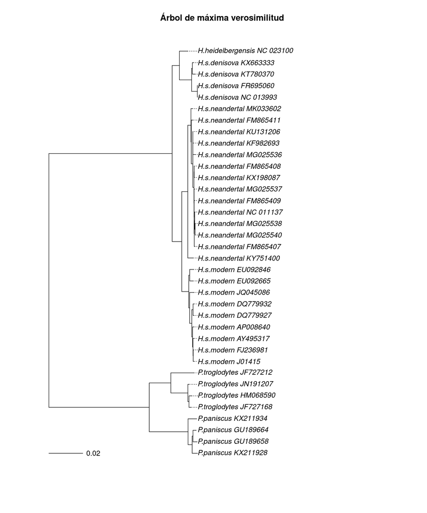

```r
plot(midpoint(mt_ml$tree),
     align.tip.label = TRUE,
     main = "Árbol de máxima verosimilitud")
add.scale.bar()
```

## Ejercicio: enraizado del árbol de máxima verosimilitud con `rtt()`

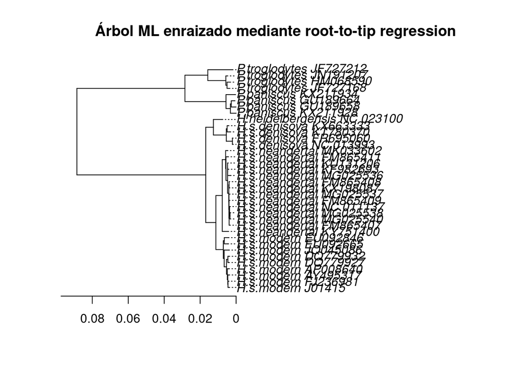

```r
fechas36 <- fechas[names(mtdna36)]

# Aseguramos que las fechas estén en el mismo orden que las puntas del árbol ML.
fechas36_tree <- fechas36[mt_ml$tree$tip.label]

mt_ml_rtt <- rtt(mt_ml$tree, tip.dates = fechas36_tree)

plot(mt_ml_rtt,
     align.tip.label = TRUE,
     main = "Árbol ML enraizado mediante root-to-tip regression")
axisPhylo()
```

El árbol de máxima verosimilitud inicial es no enraizado. La función `rtt()` usa las fechas de muestreo de las puntas para buscar una posición de la raíz compatible con una relación aproximadamente lineal entre distancia raíz-punta y edad. Dado que las diferencias temporales entre muestras arcaicas son pequeñas frente a la divergencia profunda entre linajes, este método debe interpretarse con cautela.

## Ejercicio: máxima verosimilitud solo para el género *Homo*

```r
fit_homo_inicial <- fit_homo_bic

mt_ml_homo <- optim.pml(
  fit_homo_inicial,
  optNni = TRUE,
  optBf = TRUE,
  optQ = TRUE,
  optInv = TRUE,
  optGamma = TRUE,
  control = pml.control(trace = 0)
)

mt_ml_homo
```

```
model: TrN+G(4)+I
loglikelihood: -28830.1
unconstrained loglikelihood: -45918.42
Proportion of invariant sites: 0.8149568
Model of rate heterogeneity: Discrete gamma model
Number of rate categories: 4
Shape parameter: 1.004894
        Rate Proportion
1  0.0000000 0.81495677
2  0.7453897 0.04626081
3  2.5843584 0.04626081
4  5.4084996 0.04626081
5 12.8783222 0.04626081

Rate matrix:
          a          c          g         t
a  0.000000  2.0976944 71.5444123  0.857178
c  2.097694  0.0000000  0.7120525 42.783913
g 71.544412  0.7120525  0.0000000  1.000000
t  0.857178 42.7839126  1.0000000  0.000000

Base frequencies:
        a         c         g         t
0.3088346 0.3122897 0.1312145 0.2476612
```

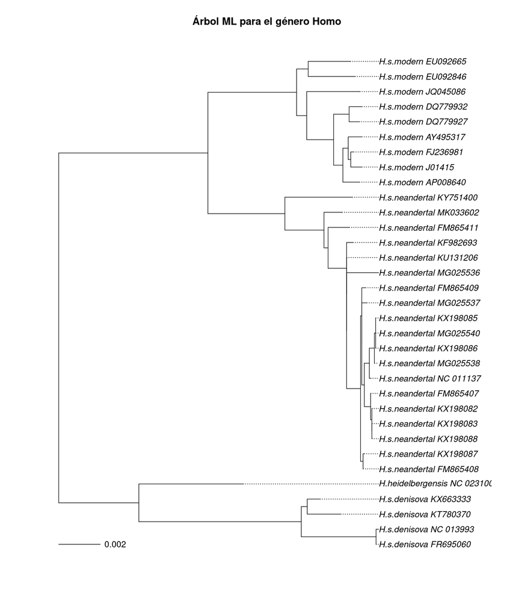

```r
plot(midpoint(mt_ml_homo$tree),
     align.tip.label = TRUE,
     main = "Árbol ML para el género Homo")
add.scale.bar()
```

# Con datación de puntas (*tip dating*)

El método de máxima verosimilitud genera árboles no enraizados por defecto porque los modelos reversibles no contienen información temporal directa. Cuando existen secuencias de distintas edades, se puede usar esa información para intentar estimar la raíz y una tasa molecular aproximada.

La función `pml_bb(..., method = "tipdated")` no está disponible en todas las instalaciones, por lo que aquí se usa una aproximación robusta con `rtt()` y funciones de `ape`.

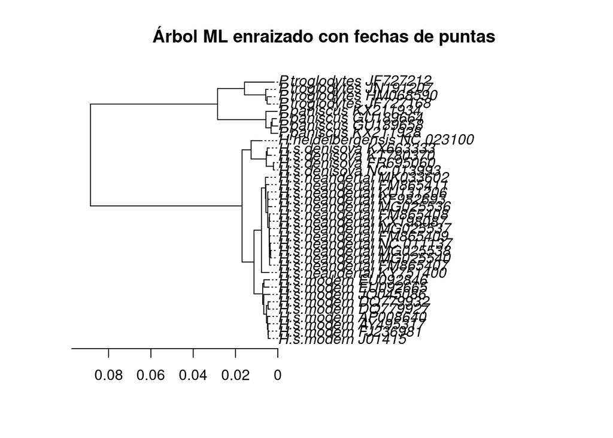

```r
fechas36 <- fechas[names(mtdna36)]
fechas36_tree <- fechas36[mt_ml$tree$tip.label]

mt_ml_clock <- rtt(mt_ml$tree, tip.dates = fechas36_tree)

plot(mt_ml_clock,
     align.tip.label = TRUE,
     main = "Árbol ML enraizado con fechas de puntas")
axisPhylo()
```

## Ejercicio: tasa de mutación global y divergencia con chimpancés

Podemos estimar una tasa aproximada mediante `estimate.mu()`, aunque en este contexto debe interpretarse con cautela.

```r
# Para estimate.mu necesitamos un vector de fechas con hojas y nodos internos.
# Primero creamos un árbol enraizado.
tree_clock <- mt_ml_clock

fechas_puntas_clock <- fechas36[tree_clock$tip.label]

fechas_nodos_clock <- c(fechas_puntas_clock,
                        rep(NA, tree_clock$Nnode))

# estimate.mu puede fallar si la calibración temporal es insuficiente.
tasa_clock <- tryCatch(
  estimate.mu(tree_clock, fechas_nodos_clock),
  error = function(e) NA_real_
)

tasa_clock
```

```
[1] 1.147798e-08
```

La tasa de mutación global estimada se expresa en sustituciones por sitio y por año si las fechas están expresadas en años. En este análisis, las fechas se han codificado como años negativos antes del presente, por lo que las ramas del árbol datado pueden interpretarse aproximadamente en unidades temporales.

```r
cof_clock <- cophenetic(tree_clock)

tips_modernos_clock <- startsWith(rownames(cof_clock), "H.s.modern")
tips_chimp_clock <- startsWith(colnames(cof_clock), "P.troglodytes")

div_hum_chimp_clock <- mean(cof_clock[tips_modernos_clock, tips_chimp_clock],
                            na.rm = TRUE)

div_hum_chimp_clock
```

```
[1] 0.1693719
```

La estimación temporal debe interpretarse de forma prudente, ya que el conjunto de datos mitocondrial no contiene suficiente señal temporal reciente para calibrar con precisión divergencias de millones de años únicamente a partir de edades de muestras arcaicas.